# Lab 10: Unsupervised Learning

The purpose of this lab is to get experience with density estimation and clustering methods.

**It is strongly recommended that you complete this lab on the VMs, but it can perhaps also be completed on any computer that has R (version >= 4.0) available. Your final R markdown document must be processed on the VMs to produce the HTML document for submission.**

# The Data Set

The source of the data we use in this lab is from [Open ML](https://www.openml.org/home/). In particular, we are going to use the `Phoneme` data set, the description of which can be found here: https://www.openml.org/d/1489.

The original `Phoneme` data set has 5404 observations. To make computation a bit faster for this assignment, I have downsized it to 1000 observations via a random subsampling, and the downsized data set is available on Canvas. You can save a local copy and read it into R as follows:

```r
phoneme = read.csv("phoneme.csv", stringsAsFactors=TRUE)
```

The data set has 5 numeric predictors and one response variable `class`, which has two levels: `Nasal` (nasal vowels) and `Oral` (oral vowels). The numerical variables have all be standardised (and followed with a rounding to 4 d.p.) to have mean 0 and standard deviation 1, as also in the original data set. A pairwise scatterplot of the data looks like the following:

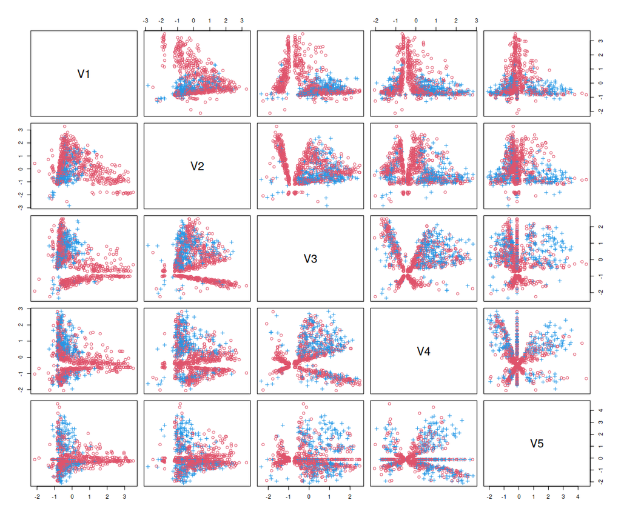

```r
with(phoneme, pairs(phoneme[,-6], col=c(2,4)[Class], pch=c(1,3)[Class]))
```

To perform the following tasks, make sure you have loaded the following library:

```r
library(mclust)
```

# Tasks

## Visualisation

1. When there are a large number of observations, observations of smaller classes may be overwhelmed in a scatterplot by those in larger classes. Therefore, one may prefer to plot the observations of larger classes first and then those of smaller ones, or for a two-class data set those of the majority class and then those of the minority one.

   Write R rode to reproduce the following plot which follows the above description. Make sure that the majority class is determined by code automatically (i.e., not by eyes) so it can be reused easily.

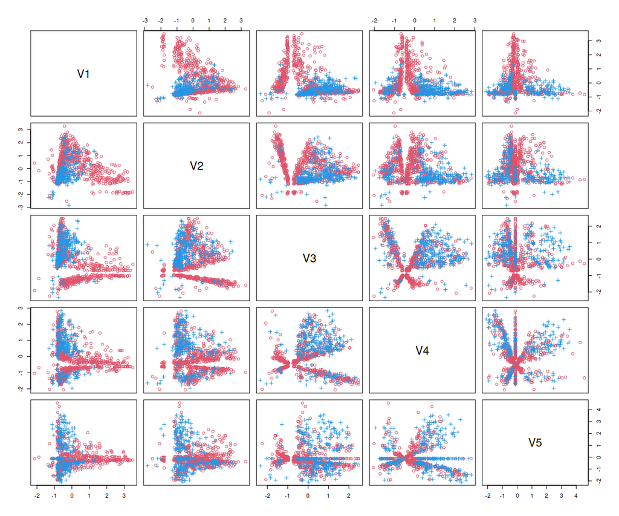

## Univariate Density Estimation

2. Plot each of the kernel density estimate, by superimposing it on a histogram (with `breaks=100`), for `V1`, with the bandwidth values chosen by methods `nrd0`, `ucv`, `bcv` and `SJ`, respectively.

   Observe and discuss if both overfitting and underfitting can exist for a KDE.
3. Find the best normal mixture fit to `V1` (according to the BIC), in both equal and varying variance subfamilies, with the number of components ranging from 1 to 20.

   Plot the fitted density, along with a histogram of the data.

   Does it look like a better or worse fit than the best of the KDEs?

## Multivariate density estimation

4. For each of the two classes, find a density estimate in the equal variance subfamily of multivariate normal mixtures, with the number of components ranging from 1 to 9.

   Show each density in a pairwise plot of the data.
5. Repeat Task 4, but for the varying variance subfamily of normal mixtures.
6. By applying the fundamental rule of classification, we obtain immediately a classifier from Tasks 4 and 5, respectively.

   For each classifier, compute its resubstitution misclassification rate.

## K-means

7. With the K-means method, find the clustering results with two clusters. Show the results in a pairwise plot of the data, using different colors and point types for observations of different clusters. (If you have successfully finished Task 1, then plot the majority cluster first.)
8. One might be curious to see if the clusters found by a clustering method are anywhere similar to the class labels that are also available in a data set (i.e., to examine the performance of an unsupervised learning method for a supervised learning problem).

   Compute the adjusted Rand indices for $K = 2, \dots, 9$ clusters as found by the K-means method, when the given class labels are contrasted. Comment on the results.

## Mixture-based clustering

9. Using the varying variance subfamily of multivariate normal mixtures, find the clustering results with two clusters, and show the results in a pairwise plot as in Task 7.

   Also compute the adjusted Rand indices for $K = 2, \dots, 9$ clusters (as done in Task 8).

## Hierarchical Clustering

10. Produce a dendrogram of the hierarchical clustering results using the complete and the single linkage method, respectively.

    Explain why they look very much different.
11. Compute the adjusted Rand indices for $K = 2, \dots, 9$ clusters produced by the complete and the single linkage method, respectively (as done in Task 8).
12. Produce the heatmaps for both the complete and single linkage methods.

# The Report

Your submission should consist of an R Markdown document, submitted via Canvas. You should write your document so that I can process it on my computer without any manual intervention. For example, do not include any calls to `setwd()` or `file.choose()`. You should write code that assumes that data ﬁles are in the current working directory or at a fixed location on the VMs. Also submit a processed version of your R Markdown document (an HTML document) in case I cannot process your document on my computer.

Your report should include:

- A brief description of the data.
- For each task, R code AND a brief text commentary.
- A summary of the entire report.

# Marking

Marks will be lost for:

- R Markdown ﬁle is missing.
- R Markdown ﬁle does not run.
- Processed ﬁle (HTML) is missing.
- Section of the report is missing.
- Unintelligible, or confusing, or irrelevant summary.
- Signiﬁcantly poor R (or other) code.
- Overly verbose code, output, or commentary.

This work is licensed under a [Creative Commons Attribution 4.0 International License](http://creativecommons.org/licenses/by/4.0/).